# **Introduction to vegan package in R**

Wyclife Agumba Oluoch (wyclifeoluoch@gmail.com)

2023-07-02 22:55:19.026278

# Background—-

In this write-up I explored `vegan` package. `vegan` is an `R` library featuring a number of important functions. I demonstrate some use cases.

# Loading the data—-

Load data that come with the `vegan` package itself.

```r
data("BCI")
```

There are plenty data, we can check the dimensions of the data frame using the `dim()` function from base `R` package.

```r
dim(BCI) # dimensions
```

```
## [1]  50 225
```

The other way of getting the number of species from each plot in the data-set is to use `specnumber()`.

```r
specnumber(BCI)
```

```
##   1   2   3   4   5   6   7   8   9  10  11  12  13  14  15  16  17  18  19  20
##  93  84  90  94 101  85  82  88  90  94  87  84  93  98  93  93  93  89 109 100
##  21  22  23  24  25  26  27  28  29  30  31  32  33  34  35  36  37  38  39  40
##  99  91  99  95 105  91  99  85  86  97  77  88  86  92  83  92  88  82  84  80
##  41  42  43  44  45  46  47  48  49  50
## 102  87  86  81  81  86 102  91  91  93
```

Remember it is possible to change the names rownames from numbers to english letters as using `english` package as follows:

```r
setNames(specnumber(BCI), english::english(1:50))
```

```
##          one          two        three         four         five          six
##           93           84           90           94          101           85
##        seven        eight         nine          ten       eleven       twelve
##           82           88           90           94           87           84
##     thirteen     fourteen      fifteen      sixteen    seventeen     eighteen
##           93           98           93           93           93           89
##     nineteen       twenty   twenty-one   twenty-two twenty-three  twenty-four
##          109          100           99           91           99           95
##  twenty-five   twenty-six twenty-seven twenty-eight  twenty-nine       thirty
##          105           91           99           85           86           97
##   thirty-one   thirty-two thirty-three  thirty-four  thirty-five   thirty-six
##           77           88           86           92           83           92
## thirty-seven thirty-eight  thirty-nine        forty    forty-one    forty-two
##           88           82           84           80          102           87
##  forty-three   forty-four   forty-five    forty-six  forty-seven  forty-eight
##           86           81           81           86          102           91
##   forty-nine        fifty
##           91           93
```

This can then be set to a data.frame as follows and possibly just check the first few rows:

```r
setNames(specnumber(BCI), english::english(1:50)) |> as.data.frame() |> head()
```

```
##       setNames(specnumber(BCI), english::english(1:50))
## one                                                  93
## two                                                  84
## three                                                90
## four                                                 94
## five                                                101
## six                                                  85
```

We can convert the `specnumber(BCI)` into a dataframe and arrange plots by the descending number of species.

```r
specnumber(BCI) |>
  as.data.frame() |>
  arrange(-specnumber(BCI))
```

```
##    specnumber(BCI)
## 19             109
## 25             105
## 41             102
## 47             102
## 5              101
## 20             100
## 21              99
## 23              99
## 27              99
## 14              98
## 30              97
## 24              95
## 4               94
## 10              94
```

[output cut: 36 more lines]

It is estimating the number of species in the pool using `specpool()` function. There are 225 species, but the estimator gives a range of values from 236 to 247 with some standard errors around them. Would be interesting to go to the back-end and look at what goes on with this function.

```r
specpool(BCI,
         smallsample = TRUE)
```

```
##     Species     chao chao.se  jack1 jack1.se    jack2     boot  boot.se  n
## All     225 236.3732 6.54361 245.58 5.650522 247.8722 235.6862 3.468888 50
```

# Calculating the diversity indices

Here we explore a data-set consisting of 50 field plots showing the number of individuals of species of trees counted in each sampling plot. A typical ecological survey study.

We can calculate species diversity in the 50 plots using **shannon** index. There are also indices like **simpson** or **invsimpson** that one can calculate from the data-set.

## Shannon index

```r
diversity(BCI,
          index = 'shannon') # Just specify the index to be shannon
```

```
##        1        2        3        4        5        6        7        8
## 4.018412 3.848471 3.814060 3.976563 3.969940 3.776575 3.836811 3.908381
##        9       10       11       12       13       14       15       16
## 3.761331 3.889803 3.859814 3.698414 3.982373 4.017494 3.956635 3.916821
##       17       18       19       20       21       22       23       24
## 3.736897 3.944985 4.013094 4.077327 3.969925 3.755413 4.062575 3.979427
##       25       26       27       28       29       30       31       32
## 4.074718 3.947749 3.980281 3.693896 3.688721 3.851598 3.724967 3.784873
##       33       34       35       36       37       38       39       40
## 3.740392 3.821669 2.641859 3.846109 3.791703 3.516082 3.530494 3.234849
##       41       42       43       44       45       46       47       48
## 4.052495 3.966614 3.736254 3.705016 3.609518 3.810489 3.920918 3.913725
##       49       50
## 3.778851 3.906616
```

## Simpson index

```r
diversity(BCI,
          index = 'simpson') # Changing the code to calculate the simpson diversity index
```

```
##         1         2         3         4         5         6         7         8
## 0.9746293 0.9683393 0.9646078 0.9716117 0.9678267 0.9627557 0.9672014 0.9671998
##         9        10        11        12        13        14        15        16
## 0.9534257 0.9663808 0.9658398 0.9550599 0.9692075 0.9718626 0.9709057 0.9686598
##        17        18        19        20        21        22        23        24
## 0.9545126 0.9676685 0.9655820 0.9748589 0.9686058 0.9548316 0.9723529 0.9694268
##        25        26        27        28        29        30        31        32
## 0.9726152 0.9709567 0.9669962 0.9499296 0.9481041 0.9602659 0.9635807 0.9565267
##        33        34        35        36        37        38        39        40
## 0.9586946 0.9607876 0.7983976 0.9648567 0.9565015 0.9365144 0.9360204 0.9137131
##        41        42        43        44        45        46        47        48
## 0.9731442 0.9731849 0.9569632 0.9578733 0.9528853 0.9646728 0.9672083 0.9676412
##        49        50
## 0.9609552 0.9679784
```

## Inverse Simpson index

```r
diversity(BCI,
          index = 'invsimpson') # The code to run inverse of simpson index
```

```
##         1         2         3         4         5         6         7         8
## 39.415554 31.584877 28.254778 35.225771 31.081658 26.849731 30.489077 30.487609
##         9        10        11        12        13        14        15        16
## 21.471056 29.744868 29.273803 22.251827 32.475442 35.539830 34.371014 31.907937
##        17        18        19        20        21        22        23        24
## 21.984098 30.929617 29.054548 39.775448 31.853042 22.139382 36.170213 32.708387
##        25        26        27        28        29        30        31        32
## 36.516636 34.431303 30.299530 19.971863 19.269343 25.167317 27.457940 23.002620
##        33        34        35        36        37        38        39        40
## 24.209883 25.502106  4.960258 28.454909 22.989309 15.751596 15.629977 11.589250
##        41        42        43        44        45        46        47        48
## 37.235945 37.292428 23.235938 23.737903 21.224806 28.306797 30.495526 30.903463
##        49        50
## 25.611603 31.228916
```

# Plots that compare the indices of the Simpson and Shannon

Relationship between Shannon and Simpson diversity indices.

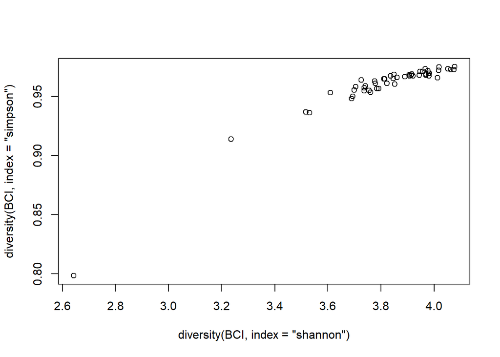

```r
plot(diversity(BCI,
               index = 'shannon'),
     diversity(BCI,
               index = 'simpson')) # Kind of linear
```

Assessing the relationship between shannon and invsimpson indices of diversity.

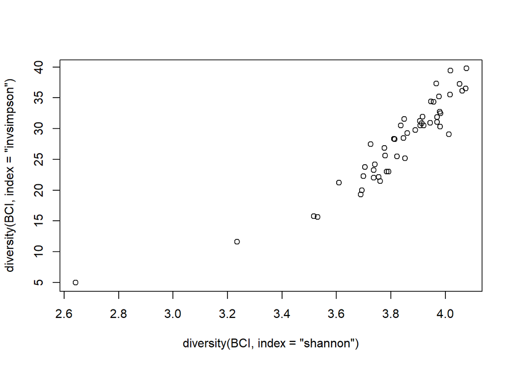

```r
plot(diversity(BCI,
               index = 'shannon'),
     diversity(BCI,
               index = 'invsimpson'))
```

Relationship between `simpson` and `invsimpson` indices of diversity.

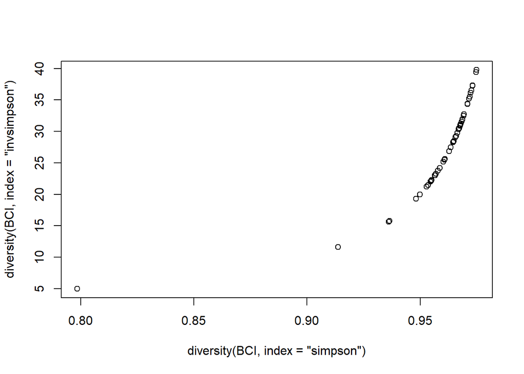

```r
plot(diversity(BCI,
               index = 'simpson'),
     diversity(BCI,
               index = 'invsimpson')) # curvilinear relationship
```

## Fisher alpha index

We can also calculate fisher.alpha for the data-set using the function `fisher.alpha()`.

```r
fisher.alpha(BCI)
```

```
##        1        2        3        4        5        6        7        8
## 35.67297 30.99091 33.32033 33.92209 37.96423 32.49374 30.58383 33.44981
##        9       10       11       12       13       14       15       16
## 35.67236 34.82320 34.20590 34.12041 37.56974 39.21837 35.07926 36.16927
##       17       18       19       20       21       22       23       24
## 39.21057 38.71442 46.85170 40.99634 41.58728 35.84847 46.92764 39.87658
##       25       26       27       28       29       30       31       32
## 43.53983 36.40222 41.03649 33.65451 35.54363 36.87417 27.62298 32.34465
##       33       34       35       36       37       38       39       40
## 32.08718 35.12348 26.11065 35.88775 33.28235 29.46136 31.41425 27.17138
##       41       42       43       44       45       46       47       48
## 44.06386 33.59822 33.31374 30.28666 29.02041 32.32598 42.56011 35.99618
##       49       50
## 35.41942 36.40426
```

# Species cumulative curve

Further, we can plot species accumulation curve for the data-set. This is showing how the number of species vary with number of plots sampled. Normally the curve flattens at some point in which case additional sampling does not yield any more new species.

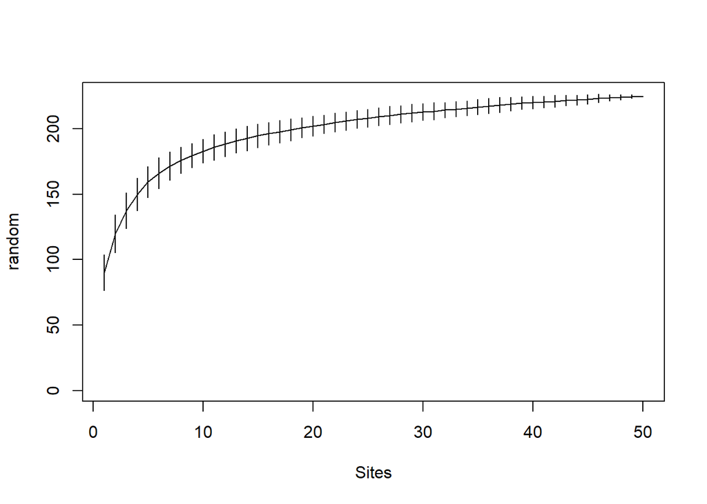

```r
plot(specaccum(comm = BCI,
               method = 'random',
               permutations = 100))
```

```r
# Other methods include rarefaction, site, collector, exact, coleman
```

# Detrended correspondence analysis

Lastly, we can check for **detrended** correspondence analysis by plot using `decorana()` function.

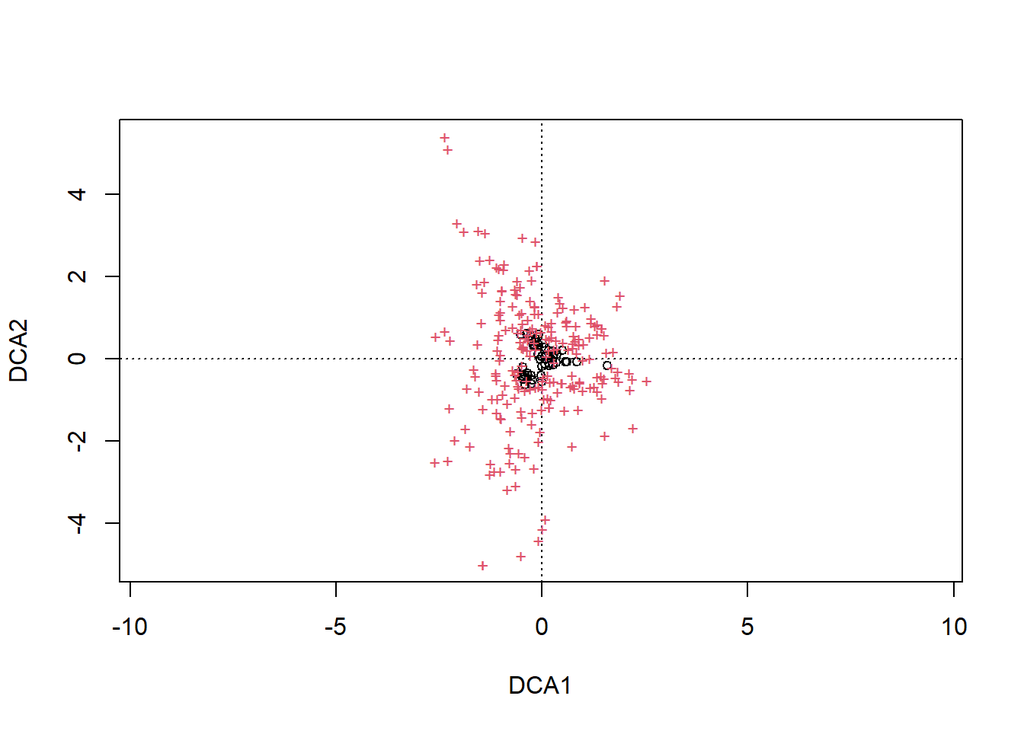

```r
plot(decorana(BCI))
```

# Engaging mite data

This has two separate data-frames, one for species per plot and the other for the environmental variables recorded from the same sampling plots as the species.

```r
data(mite)
data("mite.env")
```

```r
summary(mite.env)
```

```
##     SubsDens        WatrCont         Substrate   Shrub         Topo
##  Min.   :21.17   Min.   :134.1   Sphagn1  :25   None:19   Blanket:44
##  1st Qu.:30.01   1st Qu.:314.1   Sphagn2  :11   Few :26   Hummock:26
##  Median :36.38   Median :398.5   Sphagn3  : 1   Many:25
##  Mean   :39.28   Mean   :410.6   Sphagn4  : 2
##  3rd Qu.:46.81   3rd Qu.:492.8   Litter   : 2
##  Max.   :80.59   Max.   :827.0   Barepeat : 2
##                                  Interface:27
```

Calculating `ordiplot`. This is another plot that may need deeper understanding on how to interpret it and what it means.

```r
ordiplot(nmds1)
```

[output not shown]

```r
ordiplot(nmds1,
         type = 't')
```

[output not shown]

```r
autoplot(nmds1)
```

[output not shown]

Here I make some informative plots with forti.

```r
fort <- fortify(nmds1)
ggplot() +
  geom_point(data = subset(fort,
                           Score == 'sites'),
             mapping = aes(x = NMDS1,
                           y = NMDS2),
             color = 'black',
             alpha = 0.5) +
  geom_segment(data = subset(fort,
                             Score == 'species'),
               mapping = aes(x = 0,
                             y = 0,
                             xend = NMDS1,
                             yend = NMDS2),
               arrow = arrow(length = unit(0.015,
                                           'npc'),
                             type = 'closed'),
               color = 'darkgray',
               size = 0.8) +
  geom_text(data = subset(fort,
                          Score == 'species'),
            mapping = aes(label = Label,
                          x = NMDS1 * 1.1,
                          y = NMDS2 * 1.1)) +
  geom_abline(intercept = 0,
              slope = 0,
              linetype = 'dashed',
              size = 0.8,
              color = 'gray') +
  geom_vline(aes(xintercept = 0),
             linetype = 'dashed',
             size = 0.8,
             color = 'gray') +
  theme(panel.grid.major = element_blank(),
        panel.grid.minor = element_blank(),
        panel.background = element_blank(),
        axis.line = element_line(color = 'black'))
```

[output not shown]

```r
p1 <- ggplot() +
  geom_point(data = subset(fort, Score == 'sites'),
             mapping = aes(x = NMDS1, y = NMDS2),
             color = 'black',
             alpha = 0.5) +
  geom_segment(data = subset(fort, Score == 'species'),
               mapping = aes(x = 0, y = 0, xend = NMDS1, yend = NMDS2),
               arrow = arrow(length = unit(0.015, 'npc'),
                             type = 'closed'),
               color = 'darkgray',
               size = 0,
               alpha = 0) +
  geom_text(data = subset(fort, Score == 'species'),
            mapping = aes(label = Label, x = NMDS1 * 1.1, y = NMDS2 * 1.1),
            alpha = 0) +
  geom_abline(intercept = 0, slope = 0, linetype = 'dashed', size = 0.8, color = 'gray') +
  geom_vline(aes(xintercept = 0), linetype = 'dashed', size = 0.8, color = 'gray') +
  theme(panel.grid.major = element_blank(),
        panel.grid.minor = element_blank(),
        panel.background = element_blank(),
        axis.line = element_line(color = 'black'))
p1
```

[output not shown]

```r
p2 <- ggplot() +
  geom_point(data = subset(fort, Score == 'sites'),
             mapping = aes(x = NMDS1, y = NMDS2),
             color = 'black',
             alpha = 0) +
  geom_segment(data = subset(fort, Score == 'species'),
               mapping = aes(x = 0,
                             y = 0,
                             xend = NMDS1,
                             yend = NMDS2),
               arrow = arrow(length = unit(0.015, 'npc'),
                             type = 'closed'),
               color = 'darkgray',
               size = 0.8) +
  geom_text(data = subset(fort, Score == 'species'),
            mapping = aes(label = Label, x = NMDS1 * 1.1, y = NMDS2 * 1.1)) +
  geom_abline(intercept = 0, slope = 0, linetype = 'dashed', size = 0.8, color = 'gray') +
  geom_vline(aes(xintercept = 0), linetype = 'dashed', size = 0.8, color = 'gray') +
  theme(panel.grid.major = element_blank(),
        panel.grid.minor = element_blank(),
        panel.background = element_blank(),
        axis.line = element_line(color = 'black'))
p2
```

[output not shown]

```r
ggarrange(p1, p2, ncol = 1)
```

[output not shown]

```r
#adonis(mite ~ Shrub, data = mite.env)
```

```r
p3 <- ggplot() +
  geom_point(data = subset(fort,
                           Score == 'sites'),
             mapping = aes(x = NMDS1,
                           y = NMDS2,
                           color = mite.env$Shrub),
             alpha = 0.5) +
  geom_segment(data = subset(fort,
                             Score == 'species'),
               mapping = aes(x = 0,
                             y = 0,
                             xend = NMDS1,
                             yend = NMDS2),
               arrow = arrow(length = unit(0.015, 'npc'),
                             type = 'closed'),
               color = 'darkgray',
               size = 0,
               alpha = 0) +
  geom_text(data = subset(fort,
                          Score == 'species'),
            mapping = aes(label = Label,
                          x = NMDS1 * 1.1,
                          y = NMDS2 * 1.1),
            alpha = 0) +
  geom_abline(intercept = 0,
              slope = 0,
              linetype = 'dashed',
              size = 0.8,
              color = 'gray') +
  geom_vline(aes(xintercept = 0),
             linetype = 'dashed',
             size = 0.8,
             color = 'gray') +
  theme(panel.grid.major = element_blank(),
        panel.grid.minor = element_blank(),
        panel.background = element_blank(),
        axis.line = element_line(color = 'black'),
        legend.position = c(0.8, 0.2)) +
  scale_color_discrete("Shrubs")
p3
```

[output not shown]

These are further plots that can be created to show relationships within the data-set.

```r
ggarrange(p3,
          p2,
          ncol = 1)
```

[output not shown]

# References

Allaire, JJ, Yihui Xie, Christophe Dervieux, Jonathan McPherson, Javier Luraschi, Kevin Ushey, Aron Atkins, et al. 2023. *Rmarkdown: Dynamic Documents for r*. https://CRAN.R-project.org/package=rmarkdown.

Grolemund, Garrett, and Hadley Wickham. 2011. “Dates and Times Made Easy with lubridate.” *Journal of Statistical Software* 40 (3): 1–25. https://www.jstatsoft.org/v40/i03/.

Kassambara, Alboukadel. 2023. *Ggpubr: Ggplot2 Based Publication Ready Plots*. https://rpkgs.datanovia.com/ggpubr/.

Müller, Kirill, and Hadley Wickham. 2023. *Tibble: Simple Data Frames*. https://CRAN.R-project.org/package=tibble.

Oksanen, Jari, Gavin L. Simpson, F. Guillaume Blanchet, Roeland Kindt, Pierre Legendre, Peter R. Minchin, R. B. O’Hara, et al. 2022. *Vegan: Community Ecology Package*. https://github.com/vegandevs/vegan.

Qiu, Yixuan. 2021. *Prettydoc: Creating Pretty Documents from r Markdown*. https://github.com/yixuan/prettydoc.

R Core Team. 2023. *R: A Language and Environment for Statistical Computing*. Vienna, Austria: R Foundation for Statistical Computing. https://www.R-project.org/.

Sarkar, Deepayan. 2008. *Lattice: Multivariate Data Visualization with r*. New York: Springer. http://lmdvr.r-forge.r-project.org.

———. 2023. *Lattice: Trellis Graphics for r*. https://lattice.r-forge.r-project.org/.

Simpson, Gavin L. 2019. *Ggvegan: Ggplot2 Plots for the Vegan Package*.

———. 2022. *Permute: Functions for Generating Restricted Permutations of Data*. https://github.com/gavinsimpson/permute.

Spinu, Vitalie, Garrett Grolemund, and Hadley Wickham. 2023. *Lubridate: Make Dealing with Dates a Little Easier*. https://CRAN.R-project.org/package=lubridate.

Wickham, Hadley. 2016. *Ggplot2: Elegant Graphics for Data Analysis*. Springer-Verlag New York. https://ggplot2.tidyverse.org.

———. 2022. *Stringr: Simple, Consistent Wrappers for Common String Operations*. https://CRAN.R-project.org/package=stringr.

———. 2023a. *Forcats: Tools for Working with Categorical Variables (Factors)*. https://CRAN.R-project.org/package=forcats.

———. 2023b. *Tidyverse: Easily Install and Load the Tidyverse*. https://CRAN.R-project.org/package=tidyverse.

Wickham, Hadley, Mara Averick, Jennifer Bryan, Winston Chang, Lucy D’Agostino McGowan, Romain François, Garrett Grolemund, et al. 2019. “Welcome to the tidyverse.” *Journal of Open Source Software* 4 (43): 1686. https://doi.org/10.21105/joss.01686.

Wickham, Hadley, Winston Chang, Lionel Henry, Thomas Lin Pedersen, Kohske Takahashi, Claus Wilke, Kara Woo, Hiroaki Yutani, and Dewey Dunnington. 2023. *Ggplot2: Create Elegant Data Visualisations Using the Grammar of Graphics*. https://CRAN.R-project.org/package=ggplot2.

Wickham, Hadley, Romain François, Lionel Henry, Kirill Müller, and Davis Vaughan. 2023. *Dplyr: A Grammar of Data Manipulation*. https://CRAN.R-project.org/package=dplyr.

Wickham, Hadley, and Lionel Henry. 2023. *Purrr: Functional Programming Tools*. https://CRAN.R-project.org/package=purrr.

Wickham, Hadley, Jim Hester, and Jennifer Bryan. 2023. *Readr: Read Rectangular Text Data*. https://CRAN.R-project.org/package=readr.

Wickham, Hadley, Davis Vaughan, and Maximilian Girlich. 2023. *Tidyr: Tidy Messy Data*. https://CRAN.R-project.org/package=tidyr.

Xie, Yihui. 2014. “Knitr: A Comprehensive Tool for Reproducible Research in R.” In *Implementing Reproducible Computational Research*, edited by Victoria Stodden, Friedrich Leisch, and Roger D. Peng. Chapman; Hall/CRC.

———. 2015. *Dynamic Documents with R and Knitr*. 2nd ed. Boca Raton, Florida: Chapman; Hall/CRC. https://yihui.org/knitr/.

———. 2023. *Knitr: A General-Purpose Package for Dynamic Report Generation in r*. https://yihui.org/knitr/.

Xie, Yihui, J. J. Allaire, and Garrett Grolemund. 2018. *R Markdown: The Definitive Guide*. Boca Raton, Florida: Chapman; Hall/CRC. https://bookdown.org/yihui/rmarkdown.

Xie, Yihui, Christophe Dervieux, and Emily Riederer. 2020. *R Markdown Cookbook*. Boca Raton, Florida: Chapman; Hall/CRC. https://bookdown.org/yihui/rmarkdown-cookbook.